# Text analysis workshop: Basic sentiment analysis

Author

Casey O’Hara

```r
library(tidyverse)
library(tidytext)
library(textdata)
library(pdftools)
library(ggwordcloud)
```

# 1 Overview

Sentiment analysis is a fairly basic way to get a sense of the mood of a piece of text. In an eco-data-science sense, we can use sentiment analysis to understand perceptions of topics in environmental policy.

A good example is “Public Perceptions of Aquaculture: Evaluating Spatiotemporal Patterns of Sentiment around the World” by local celebrities Halley Froehlich, Becca Gentry, and Ben Halpern, in which they examine public perceptions of aquaculture by performing sentiment analyses on newspaper headlines from around the globe and government-solicited public comments on aquaculture policy and development. This paper is included in the ‘pdfs’ folder on Github, or [available here.](http://journals.plos.org/plosone/article?id=10.1371/journal.pone.0169281)

Another popular use of sentiment analysis is to determine the mood of Twitter comments. One excellent example is an examination of Trump tweets, which noted that tweets from an iPhone and an Android phone were markedly different in tone; the thought was that the Android account (with generally far more negative tweets) was run by Trump while the iPhone (with generally more postive tweets) was tweets from a staffer. [See here for details.](http://varianceexplained.org/r/trump-tweets/)

# 2 Prep data: Game of Thrones

## 2.1 Read in text from pdf

```r
got_text <- pdf_text(here::here('pdfs', 'got.pdf'))
```

- Each row is a page of the PDF (i.e., this is a vector of strings, one for each page)
- Only sees text that is “selectable”

Example: Just want to get text from a single page?

```r
got_page <- got_text[12]
```

`pdf_text()` returns a vector of strings, one for each page of the pdf. So we can mess with it in tidyverse style, let’s turn it into a dataframe, and keep track of the pages. Then we can use `stringr::str_split()` to break the pages up into individual lines. Each line of the pdf is concluded with a backslash-n, so split on this. We will also add a line number in addition to the page number.

Let’s first get it into a data frame. Then we’ll do some wrangling with the tidyverse, break it up by chapter and main character, and do some analyses.

```r
got_lines <- data.frame(got_text) %>%
  mutate(page = 1:n()) %>%
  mutate(text_full = str_split(got_text, pattern = '\\n')) %>%
  unnest(text_full) %>%
  mutate(text_full = str_trim(text_full))

# Why '\\n' instead of '\n'? Because some symbols (e.g. \, *) need to be called literally with a starting \ to escape the regular expression. For example, \\a for a string actually contains literally \a. So the string that represents the regular expression '\n' is actually '\\n'.

# More information: https://cran.r-project.org/web/packages/stringr/vignettes/regular-expressions.html
```

## 2.2 Do some tidying

Now, we’ll add a new column that contains the main character name (so we can use this as a grouping variable later on). Game of Thrones chapters are named after the character whose point of view is presented in the chapter. Because we cannot search for the word “Chapter” like we could for Harry Potter or The Hobbit, we’ll need to come up with a different means of identifying the start of a new chapter.

Examine the `got_lines` and scroll down to lines 530-545 to find a chapter break (or open the PDF). The title of the chapters are character names, in all caps, which is helpful in our case. But because the PDF lists the chapter names as a big capital followed by small caps, R reads in those as the first letter, followed by a few spaces, then the rest of the name.

- We will use `str_detect()` to look for any cells in “text_full” column that contain only capital letters - no punctuation, no lower case letters, but maybe a space - we will put that line into a new column as the chapter/main character name.
- Let’s also skip the first few pages, which are table of contents etc.
- Finally, let’s remove the spaces from the character names and then put the names into title case instead of all caps!

```r
got_chars <- got_lines %>%
  filter(page >= 9) %>%
  filter(page < 549) %>%
  ### check if a line is all caps, i.e., chapter header!
  mutate(allcaps = str_detect(text_full, "^[A-Z ]+$")) %>%
    ### the ^ outside [...] means "start of line", the $ means "end of line",
    ### [A-Z ] means "match any cap letter or space", and
    ### the + means "one or more of the preceding thing".
    ### NOTE: if you see a ^ inside the [...] it means NOT matching... confusing!
  mutate(main_char = ifelse(allcaps, text_full, NA)) %>%
    ### could do the regex in the ifelse, but split out so we can see it
    ### more easily... when done, let's drop the column:
  select(-allcaps) %>%
  fill(main_char, .direction = 'down') %>%
  mutate(main_char = str_remove_all(main_char, ' '),
         main_char = str_to_title(main_char),
         main_char = fct_inorder(main_char))

### how many lines of text for each character?
got_chars$main_char %>% table()
```

```
.
Prologue     Bran  Catelyn Daenerys   Eddard      Jon     Arya   Tyrion
     286     2034     3333     2928     3928     2674     1486     2766
   Sansa
    1660
```

## 2.3 Get some word counts by main character!

```r
got_words <- got_chars %>%
  unnest_tokens(word, text_full) %>%
  select(-got_text)
```

```r
got_wordcount <- got_words %>%
  group_by(main_char, word) %>%
  summarize(n = n(), .groups = 'drop')

head(got_wordcount %>% arrange(desc(n)), 10)
```

```
# A tibble: 10 × 3
   main_char word      n
   <fct>     <chr> <int>
 1 Eddard    the    3308
 2 Daenerys  the    2669
 3 Catelyn   the    2613
 4 Tyrion    the    2249
 5 Jon       the    2210
 6 Bran      the    1890
 7 Daenerys  and    1492
 8 Eddard    and    1431
 9 Catelyn   and    1396
10 Arya      the    1283
```

…OK, but check out which words show up the most. They’re probably not words we’re super interested in (like “a”, “the”, “and”). How can we limit those?

## 2.4 Remove stop words

Those very common (and often uninteresting) words are called “stop words.” See `?stop_words` and `View(stop_words)`to look at documentation for stop words lexicons (from the `tidytext` package).

We will *remove* stop words using `tidyr::anti_join()`, which will *omit* any words in `stop_words` from `got_tokens`.

```r
head(stop_words)
```

```
# A tibble: 6 × 2
  word      lexicon
  <chr>     <chr>
1 a         SMART
2 a's       SMART
3 able      SMART
4 about     SMART
5 above     SMART
6 according SMART
```

```r
got_words_clean <- got_words %>%
  anti_join(stop_words, by = 'word')
```

Then let’s try counting them again:

```r
nonstop_counts <- got_words_clean %>%
  group_by(main_char, word) %>%
  summarize(n = n(), .groups = 'drop')
head(nonstop_counts %>% arrange(desc(n)), 10)
```

```
# A tibble: 10 × 3
   main_char word        n
   <fct>     <chr>   <int>
 1 Eddard    ned       631
 2 Jon       jon       544
 3 Tyrion    tyrion    517
 4 Eddard    lord      397
 5 Daenerys  dany      393
 6 Catelyn   catelyn   379
 7 Bran      bran      378
 8 Catelyn   lord      297
 9 Arya      arya      284
10 Sansa     sansa     272
```

## 2.5 Find the top 5 words from each character

Let’s exclude mention of the character’s own name!

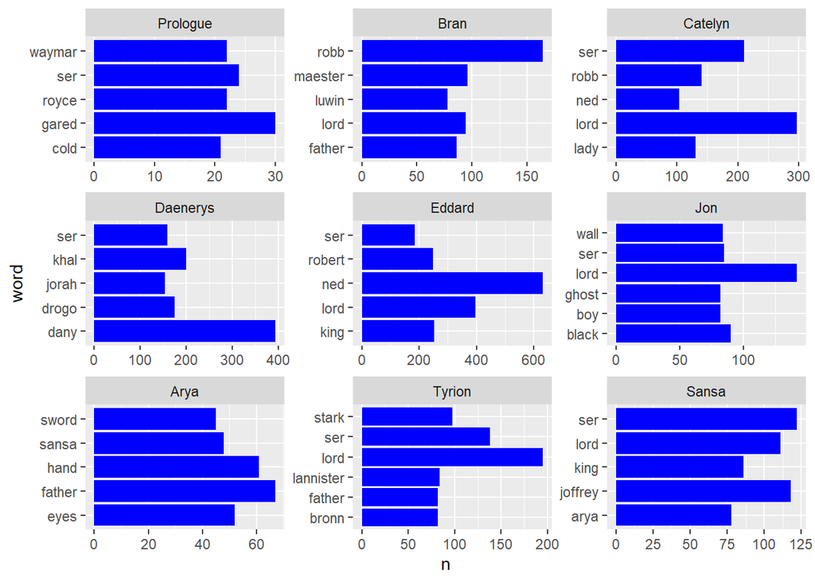

```r
top_5_words <- nonstop_counts %>%
  filter(word != str_to_lower(main_char)) %>%
  group_by(main_char) %>%
  slice_max(order_by = n, n = 5) %>%
  ungroup()

# Make some graphs:
ggplot(data = top_5_words, aes(x = n, y = word)) +
  geom_col(fill = "blue") +
  facet_wrap(~main_char, scales = "free")
```

## 2.6 Let’s make a word cloud for Eddard Stark

```r
eddard_top100 <- nonstop_counts %>%
  filter(main_char == 'Eddard') %>%
  filter(!word %in% c('eddard', 'ned')) %>%
  arrange(-n) %>%
  slice(1:100)
```

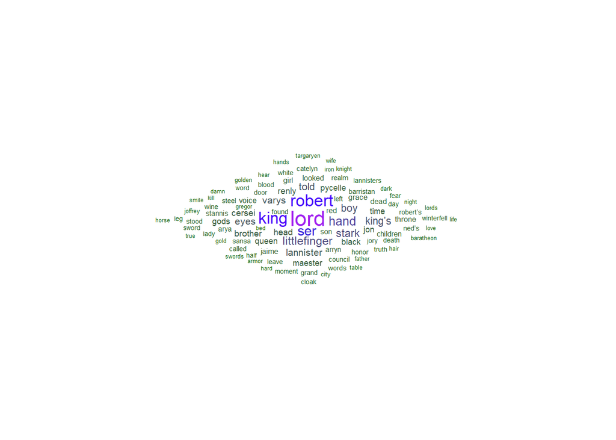

```r
eddard_cloud <- ggplot(data = eddard_top100, aes(label = word)) +
  geom_text_wordcloud(aes(color = n, size = n), shape = "diamond") +
  scale_size_area(max_size = 6) +
  scale_color_gradientn(colors = c("darkgreen","blue","purple")) +
  theme_minimal()

eddard_cloud
```

# 3 Sentiment analysis: Game of Thrones

First, check out the ‘sentiments’ lexicons. From Julia Silge and David Robinson (https://www.tidytextmining.com/sentiment.html):

“The three general-purpose lexicons are

- AFINN from Finn Årup Nielsen,
- bing from Bing Liu and collaborators, and
- nrc (National Research Council Canada) from Saif Mohammad and Peter Turney

All three of these lexicons are based on unigrams, i.e., single words. These lexicons contain many English words and the words are assigned scores for positive/negative sentiment, and also possibly emotions like joy, anger, sadness, and so forth. The nrc lexicon categorizes words in a binary fashion (“yes”/“no”) into categories of positive, negative, anger, anticipation, disgust, fear, joy, sadness, surprise, and trust. The bing lexicon categorizes words in a binary fashion into positive and negative categories. The AFINN lexicon assigns words with a score that runs between -5 and 5, with negative scores indicating negative sentiment and positive scores indicating positive sentiment. All of this information is tabulated in the sentiments dataset, and tidytext provides a function `get_sentiments()` to get specific sentiment lexicons without the columns that are not used in that lexicon.”

Let’s explore the sentiment lexicons. “bing” included, other lexicons (“afinn”, “nrc”, “loughran”) you’ll be prompted to to download.

**WARNING:** These collections include the most offensive words you can think of.

“afinn”: Words ranked from -5 (very negative) to +5 (very positive)

```r
afinn_lex <- get_sentiments(lexicon = "afinn")
### you may be prompted to download an updated lexicon - say yes!

# Let's look at the pretty positive words:
afinn_pos <- get_sentiments("afinn") %>%
  filter(value >= 4)

# Check them out:
DT::datatable(afinn_pos)
```

|  | word | value |
| --- | --- | --- |
| 1 | amazing | 4 |
| 2 | awesome | 4 |
| 3 | breathtaking | 5 |
| 4 | brilliant | 4 |
| 5 | ecstatic | 4 |
| 6 | euphoric | 4 |
| 7 | exuberant | 4 |
| 8 | fabulous | 4 |
| 9 | fantastic | 4 |
| 10 | fun | 4 |

[output cut: 40 more lines]

For comparison, check out the bing lexicon:

```r
bing_lex <- get_sentiments(lexicon = "bing")
```

And the nrc lexicon:https://saifmohammad.com/WebPages/NRC-Emotion-Lexicon.htm Includes bins for 8 emotions (anger, anticipation, disgust, fear, joy, sadness, surprise, trust) and positive / negative.

**Citation for NRC lexicon**: Crowdsourcing a Word-Emotion Association Lexicon, Saif Mohammad and Peter Turney, Computational Intelligence, 29 (3), 436-465, 2013.

Now nrc:

```r
nrc_lex <- get_sentiments(lexicon = "nrc")
```

## 3.1 Sentiment analysis with bing:

First, bind words in `got_nonstop_words` to `bing` lexicon:

```r
got_bing <- got_words_clean %>%
  inner_join(bing_lex, by = 'word')
```

Let’s find some counts of positive vs negative:

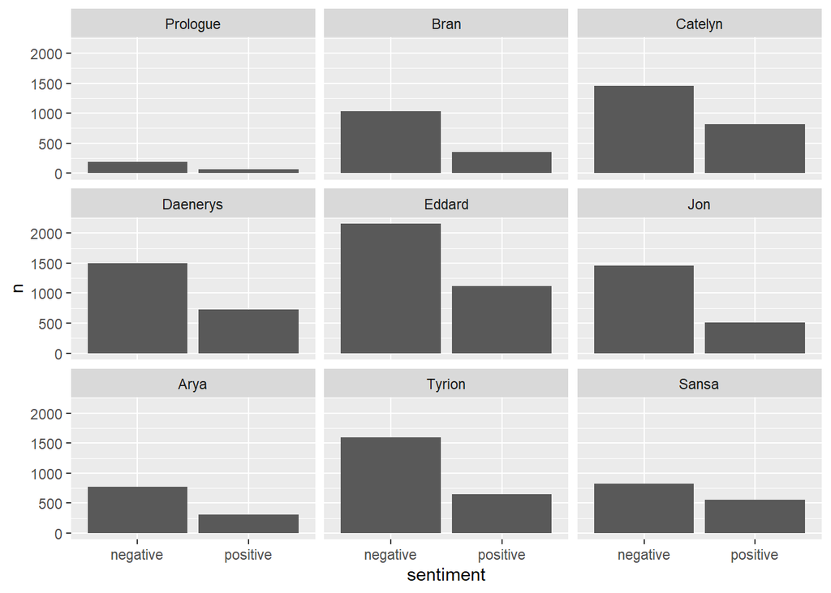

```r
bing_counts <- got_bing %>%
  group_by(main_char, sentiment) %>%
  summarize(n = n(), .groups = 'drop')

# Plot them:
ggplot(data = bing_counts, aes(x = sentiment, y = n)) +
  geom_col() +
  facet_wrap(~main_char)
```

Taking the ratio of positive to negative, rather than the total counts per character, adjusts for some characters just having fewer chapters or shorter chapters. Highly negative chapters would have a value between 0 and 1, highly positive could go from 1 to infinity, so that’s a problem. Plotting as log ratio, i.e., $\ln\left(\frac{positive}{negative}\right)$, balances that so a chapter with 10:1 positive:negative would have the same absolute value as a chapter with 1:10 positive:negative.

We might also need to consider that the overall tone of the author’s prose is darker or lighter, so let’s find the *overall* log ratio for the entire book, and subtract that out.

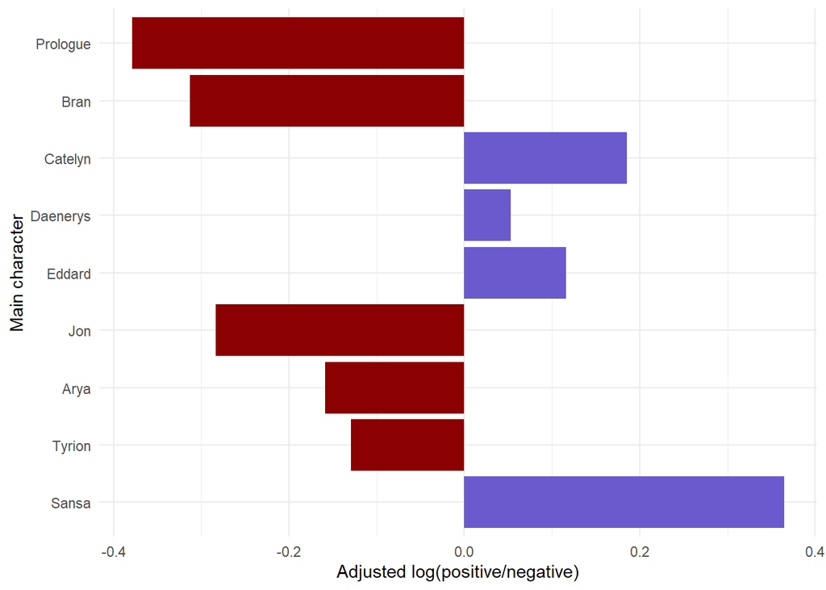

```r
# find log ratio score overall:
bing_log_ratio_book <- got_bing %>%
  summarize(n_pos = sum(sentiment == 'positive'),
            n_neg = sum(sentiment == 'negative'),
            log_ratio = log(n_pos / n_neg))

# Find the log ratio score by main_char:
bing_log_ratio_ch <- got_bing %>%
  group_by(main_char) %>%
  summarize(n_pos = sum(sentiment == 'positive'),
            n_neg = sum(sentiment == 'negative'),
            log_ratio = log(n_pos / n_neg)) %>%
  mutate(log_ratio_adjust = log_ratio - bing_log_ratio_book$log_ratio) %>%
  mutate(pos_neg = ifelse(log_ratio_adjust > 0, 'pos', 'neg'))

ggplot(data = bing_log_ratio_ch,
       aes(x = log_ratio_adjust,
           y = fct_rev(factor(main_char)),
           fill = pos_neg)) +
           # y = fct_rev(as.factor(main_char)))) +
  geom_col() +
  labs(x = 'Adjusted log(positive/negative)',
       y = 'Main character') +
  scale_fill_manual(values = c('pos' = 'slateblue', 'neg' = 'darkred')) +
  theme_minimal() +
  theme(legend.position = 'none')
```

## 3.2 Sentiment analysis with afinn (not run in workshop):

First, bind words in `got_nonstop_words` to `afinn` lexicon:

```r
got_afinn <- got_words_clean %>%
  inner_join(afinn_lex, by = 'word')
```

Let’s find some counts (by sentiment ranking):

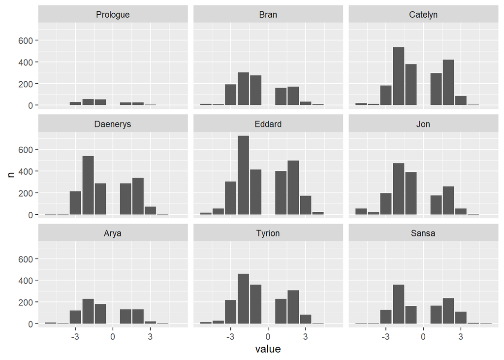

```r
afinn_counts <- got_afinn %>%
  group_by(main_char, value) %>%
  summarize(n = n())

# Plot them:
ggplot(data = afinn_counts, aes(x = value, y = n)) +
  geom_col() +
  facet_wrap(~main_char)
```

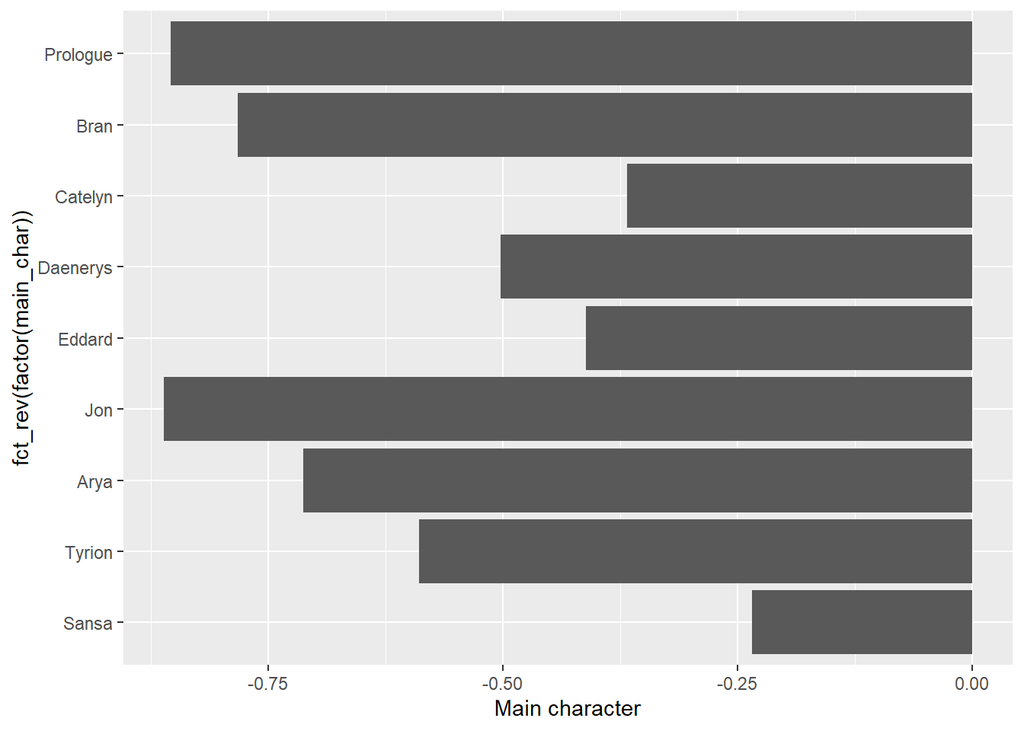

```r
# Find the mean afinn score by main_char:
afinn_means <- got_afinn %>%
  group_by(main_char) %>%
  summarize(mean_afinn = mean(value))

ggplot(data = afinn_means,
       aes(x = fct_rev(factor(main_char)),
           y = mean_afinn)) +
           # y = fct_rev(as.factor(main_char)))) +
  geom_col() +
  coord_flip() +
  labs(y = 'Main character')
```

### 3.2.1 Now with NRC lexicon (not run in workshop)

Recall, this assigns words to sentiment bins. Let’s bind our hp data to the NRC lexicon:

```r
got_nrc <- got_words_clean %>%
  inner_join(get_sentiments("nrc"))
```

Let’s find the count of words by character and sentiment bin:

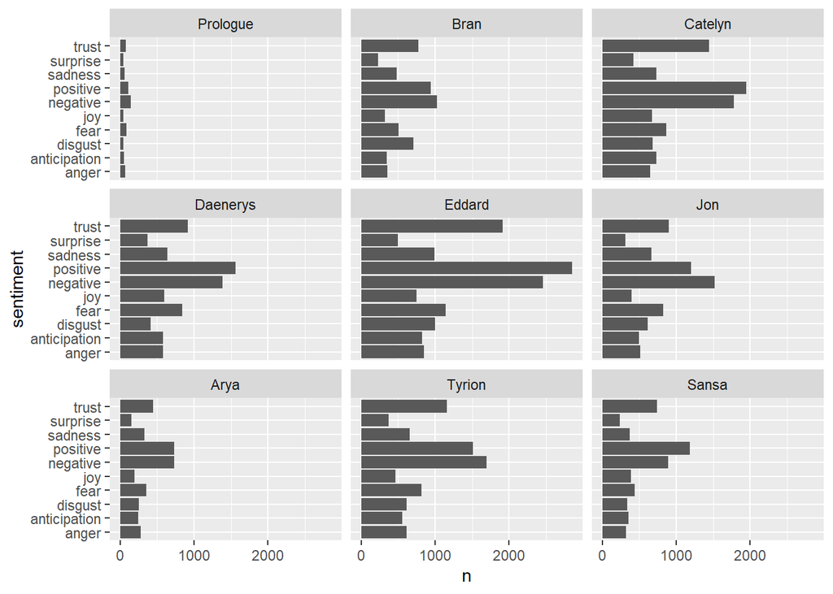

```r
got_nrc_counts <- got_nrc %>%
  group_by(main_char, sentiment) %>%
  summarize(n = n()) %>%
  ungroup()

ggplot(data = got_nrc_counts, aes(x = n, y = sentiment)) +
  geom_col() +
  facet_wrap(~main_char)
```

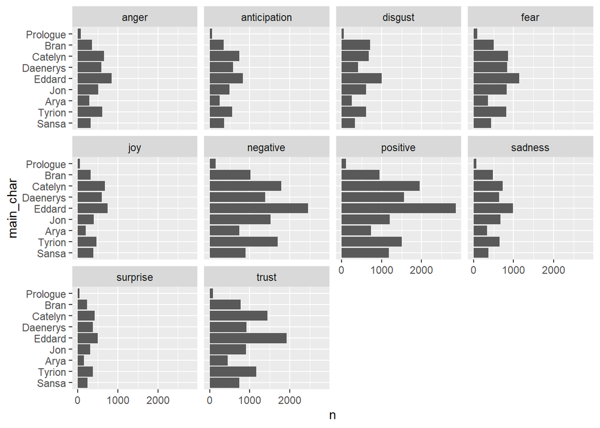

```r
### perhaps order or color the sentiments by positive/negative

ggplot(data = got_nrc_counts,
       aes(x = n, y = factor(main_char) %>% fct_rev())) +
  geom_col() +
  facet_wrap(~sentiment) +
  labs(y = 'main_char')
```

## 3.3 NOTE:

This is a very simple sentiment analysis. The `sentimentr` package (https://cran.r-project.org/web/packages/sentimentr/index.html) seems to be able to parse things at the sentence level, accounting for negations etc. (e.g. “I am not having a good day.”)